# Sta-209 Lab #3 - Correlation and Regression

In this lab we will apply what we’ve learned about summary statistics, graphs, correlation, and regression to a real dataset. The data we’ll analyze was collected by a faculty member at the University of Iowa, at the time they were looking to buy a house in Iowa City. The faculty member gathered data from the Johnson County government with the goal of using statistical methods to make sure they’d get a good deal.

## The Data

- *Sale.amount* - How much (in dollars) the house sold for
- *Sale.date* - The date when the house was sold
- *Occupancy* - A categorical variable describing how the property is designated
- *Style* - A categorical variable describing the home’s style
- *Built* - The year in which the home was constructed
- *Bedrooms* - The number of bedrooms
- *Bsmt* - The type of basement (full, none, 1/2, 3/4, or Crawl)
- *Ac* - Whether or not the home has central air conditioning
- *Attic* - Does the home have an attic and how is it set-up/accessed
- *Area.base* - Area of the ground floor (in square feet) of the home
- *Area.add* - Additional area (in square feet), not including the basement or garage
- *Area.garage1* - Area (in square feet) of the attached garage
- *Area.garage2* - Area (in square feet) of the detached garage
- *Area.living* - Total area (in square feet) of the home’s livable space
- *Area.lot* - Area of the lot (in square feet) that the house is built on
- *Lon* - The longitudinal coordinate of the home’s location
- *Lat* - The latitude of the home’s location
- *Assessed* - The home’s assessed value (in dollars) by the Iowa City Assessor

## The Goal

In this lab we will focus on a few different research questions:

1. “How are various home attributes related with the home’s sale price?”
2. “Can we predict a home’s sale price based upon its attributes?”
3. “Can we determine if a home’s sale price is a good deal?”

## Exploratory Analysis Part 1 - Learning about the variables

The first step in any statistical analysis should be to explore and understand the variables in your data. In doing so, some common considerations are:

- How were the data collected? Is it a sample or a population? What population(s) might it be representative of?
- How are the variables measured? Which are quantitative and which are categorical?
- How are the variables distributed? Do they have any outliers?
- How are the variables related? Are there any patterns or associations?

We’ll begin by exploring these considerations in the following questions:

**Question #1**

Are these data a population or a sample? Could it depend upon the research question? If they are a sample, what population(s) might they represent?

**Question #2**

Construct a one-way frequency table of the variable “Style”. Include this table in your lab write-up, along with one sentence describing an interesting piece of information you learned from the table.

**Question #3**

Report the mean, standard deviation, and five number summary of the variable “Area.living”. Is this variable skewed or symmetric? Briefly explain how you can determine symmetry or skew *without plotting the variable*.

**Question #4**

Construct side-by-side boxplots for the variables “Assessed” and “Sale.amount”. Include your plot in your lab write-up, along with a sentence describing something that you learned from the plot.

**Question #5**

Explore three additional variables using the appropriate plots or summary statistics. In your lab write-up, report *one* of these variables, and include the plot/statistic(s) you used, along with a sentence describing what you learned about the variable.

## Exploratory Analysis Part 2 - Identifying variable relationships

Now that we’ve gotten a feel for some of the variables in the data, the next step is to get an understanding of how these variables relate to each other. Oftentimes there are too many possibilities to exhaustively study each different two-variable combination (let alone combinations involving three or more variables!). Instead, we try to focus only on the variables we think will be most important in answering our research questions. Importance is generally determined from your background knowledge of the topic (or your collaborator’s knowledge in more advanced applications).

Deciding upon variables of interest before jumping in to statistical analyses also helps protect against [“data dredging” or “p-hacking”](https://en.wikipedia.org/wiki/Data_dredging). The more variables you look at, the more likely it is for a variable to appear important just by random chance (rather than real, meaningful associations).

**Question #6**

Using your personal knowledge of housing, identify five explanatory variables that you believe are associated with a home’s sale price. Make sure that you choose *at least two quantitative* and *two categorical variables*. List your choices in your lab write-up.

**Question #7**

Explore how the variables you chose in Lab Question #6 relate to each other, and how they the outcome variable “Sale.amount”. While this requires several graphs/tables/sets of summary statistics, I’d like you to include only the three graphs/tables/statistics that you found most interesting in your lab write-up. For each I’d like you to also include 1-2 sentences describing what that they tell you.

## Analyzing the Data - Research Question #1

Now that we’ve thoroughly explored the variables in the data, it is time to address our research questions. We will begin with first question: “How do various home attributes relate to a home’s sale price?”

**Question #8**

Describe how you could use summary statistics to determine which of the *quantitative variables* you chose in Lab Question #6 are most strongly associated with “Sale.amount”. After providing a 1-2 sentence explanation, use the approach you described to determine which variable is most strongly associated “Sale.amount”; be sure to include the relevant statistics in your answer.

**Question #9**

Describe how you could use summary statistics to determine which of the *categorical variables* you chose in Lab Question #6 are most strongly associated with “Sale.amount”. After providing a 1-2 sentence explanation, use the approach you described to determine which variable is most strongly associated “Sale.amount”; be sure to include the relevant statistics in your answer.

## Analyzing the Data - Research Question #2

Now let’s move on the second research question: “Can we predict a home’s sale price based upon its attributes?” We’ve already seen that predictions can be made using either the correlation coefficient or the regression line. We’ll practice both approaches here, although in practice regression tends to be the preferred method for making predictions.

**Question #10**

In Lab Question #8 you identified a quantitative variable that is most strongly associated with “Sale.amount”. For this question I’d like you to use the correlation coefficient between that variable and “Sale.amount” to predict the sale price of a home that is 1.5 standard deviations above average for the variable you identified. Show all calculations in your lab write-up.

Now let’s move on to regression. There are many ways that regression is implemented in Minitab, while they all produce the same regression line, the other information they provide to accompany that line can be somewhat different. For the purposes of this lab, I suggest fitting the regression line using the following:

1. Navigate to “Stat” -> “Regression” -> “Fitted Line Plot”
2. Select your response (Y) and explanatory (X) variables
3. Indicate that the type of regression model you want is “Linear” and click “Ok” to fit the model

You should see output that looks something like this:

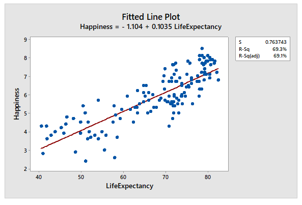

- The slope (0.1035) and intercept (-1.104) of the regression line equation are given at the top of the plot
- The plot also provides three other pieces of information: $S$, $R^2$, and adjusted $R^2$
  - $S$ measures the variability of the regression equation, you can think of it as average distance of the observed values from the regression line. [Click this link if you’d like to know more](http://blog.minitab.com/blog/adventures-in-statistics-2/regression-analysis-how-to-interpret-s-the-standard-error-of-the-regression)
  - The **coefficient of determination**, or $R^2$, is a summary statistic that conveys the proportion of variability in the outcome variable, Y, that can be explained by the explanatory variable, X:

  $$R^2 = \frac{\text{Total squared deviation of the predictions from the mean}}{\text{Total squared deviation of the observed data from the mean}} = \frac{\sum_i (\hat{y}_i - \bar{y})^2}{\sum_i (y_i - \bar{y})^2}$$
  - In the example plot, about 69% of the variation in a country’s happiness can be explained by its life expectancy
  - Adjusted $R^2$ is something we will discuss later in this course

**Question #11**

Take the square root of your $R^2$ value; have you seen this number earlier in the lab?

**Question #12**

Use your fitted regression line to predict the sale price of a home that is 1.5 standard deviations above average in your explanatory variable. Include your fitted line plot in your results and show the calculations you used to make your prediction.

## Analyzing the Data - Research Question #3

Let’s now move on to the final research question: “How can we determine if a home’s sale price is a good deal?”

**Question #13**

Considering the variable you identified in Lab Question #8 (the explanatory variable in your regression line), explain, in non-statistical terms, what a “good deal” means in regards to this variable and “Sale.amount”.

**Question #14**

Considering the variable you identified in Lab Question #8 (the explanatory variable in your regression line), explain, using the statistical concept of residuals, what a “good deal” means in regards to this variable and “Sale.amount”.

Now it’s time to see how to access the residuals of a regression line in Minitab. A simple way of doing this is to use a formula (like those we used on the first day of class). There are other ways that we can see the residuals in Minitab, but we will wait until later in the course to explore those features more thoroughly.

**Question #15**

Using a Minitab formula, create a new variable called “sale.residuals” that contains the residual of each home’s predicted sale price. Include a screenshot (ie: use the snipping tool) of your formula in your lab write-up.

**Question #16**

Using your new variable, “sale.residuals”, identify the home that you found to be the best deal. In your lab write-up, include the information on this home’s actual sale price, its predicted sale price, and a short explanation of why it is a good deal (you should reference the explanatory variable and your regression line in this explanation).

## On Your Own

Now that you’ve gotten some guided practice answering three different research questions, it is time to try doing so on your own.

**Question #17**

For Lab Question #17, I’d like you to include in your lab write-up:

1. A clearly research question that is answerable using these data.
2. 1-2 sentences describing the statistical approach you used to answer that question.
3. Any relevant summary statistics, graphs, peices of information that accompany your chosen statistical approach.
4. 1-2 sentences describing your conclusion.

You may address these items using numbered bullets or any other format you believe to be effective.